# Processing of Sequencing Data

Fabian Roger

18 Nov 2015

This scripts describes the downstream analysis of the OTU data. The part that goes from the raw Illumina data to quality filtered data was performed by Lucas Sinclair with his [Illuminatag](https://github.com/limno/illumitag) pipeline.

This pipeline includes:

- Length cutoff
- Quality filtering
- Remove reads with undetermined bases
- Primer presence check
- Assembly (aka. joining)
- Demultiplexing

The joined and quality filtered files produced by this pipeline are in the `OTU_docs/quality_reads directory`

```bash
ls OTU_docs/quality_reads
```

```
## pool1_reads.fasta
## pool2_reads.fasta
## pool3_reads.fasta
```

first we cat the files so that we can analyse them together, not separately

```bash
cat OTU_docs/quality_reads/pool1_reads.fasta OTU_docs/quality_reads/pool2_reads.fasta OTU_docs/quality_reads/pool3_reads.fasta > OTU_docs/qiime_merged.fasta
```

next we dereplicate the reads. This means, that all identical reads will be merged and a size annotation will be added to the header, saying how many reads of a given read were found.

from here on we will do the majority of the analysis in usearch

```bash
usearch
```

```
## usearch v8.1.1825_i86osx32, 4.0Gb RAM (8.6Gb total), 4 cores
## (C) Copyright 2013-15 Robert C. Edgar, all rights reserved.
## http://drive5.com/usearch
##
## Licensed to: fabian.roger@gu.se
```

as Usearch uses progress bars to track progress, I will redirect the output into an `output.tmp` file from which I can only print the last lines containing the summery statistic of the completed process

```bash
usearch -derep_fulllength OTU_docs/qiime_merged.fasta -fastaout OTU_docs/uniques.fasta -sizeout 2> output.tmp
```

```
## 00:51 1.3Gb   79.8% Writing OTU_docs/uniques.fasta
## 00:52 1.3Gb   87.4% Writing OTU_docs/uniques.fasta
## 00:53 1.3Gb   95.3% Writing OTU_docs/uniques.fasta
## 00:53 1.3Gb  100.0% Writing OTU_docs/uniques.fasta
```

no we sort the unique sequences by cluster size.

**in this step we will exclude all global singletons**

see the discussion [here](http://drive5.com/usearch/manual/singletons.html) for why.

In short, singletons are likely to not represent biological sequences and should therefor not be included for the OTU clustering. This *doesn’t* mean that we exclude all the sequences as these will be mapped back to the OTUs after OTU clustering.

```bash
usearch -sortbysize OTU_docs/uniques.fasta -fastaout OTU_docs/seqs_sorted.fasta -minsize 2 2> output.tmp
```

```
## 00:04 207Mb    0.0% Writing output
## 00:05 207Mb    3.9% Writing output
## 00:06 207Mb   51.9% Writing output
## 00:06 207Mb  100.0% Writing output
```

no we cluster the remaining sequences with an OTU radius of 3%. Robert Edgar discusses this [here](http://drive5.com/usearch/manual/cmd_cluster_otus.html). Note that this is not necessarily equivalent to the 97% identity clustering of other pipelines. As 3% is the difference form the **centroid** sequence, some people argue that 1.5% radius would be the equivalent (3% maximum difference). For this analyses however, we keep the clustering at 3%

> The -otu_radius_pct option specifies the OTU “radius” as a percentage, i.e. the maximum difference between an OTU member >sequence and the representative sequence of that OTU. Default is 3.0, corresponding to a minimum identity of 97%.

```bash
usearch -cluster_otus OTU_docs/seqs_sorted.fasta -otus OTU_docs/otus.fasta -otu_radius_pct 3 2> output.tmp
```

```
## 00:11  41Mb   81.9% 956 OTUs, 3598 chimeras (6.8%)
## 00:12  41Mb   88.5% 998 OTUs, 4000 chimeras (7.0%)
## 00:13  41Mb   95.0% 1059 OTUs, 4366 chimeras (7.1%)
## 00:13  41Mb  100.0% 1103 OTUs, 4674 chimeras (7.3%)
```

now we proceed to chimera checking using the rdp gold reference database. The database was downloaded in 2014-10-22

```bash
usearch -uchime_ref OTU_docs/otus.fasta -db OTU_docs/reference_files/rdp_gold.fasta -uchimeout OTU_docs/results.uchime -uchimealns OTU_docs/uchimealns.txt -chimeras OTU_docs/chimeras.fasta -nonchimeras OTU_docs/nonchimeras.fasta -strand plus 2> output.tmp
```

```
## 00:07 157Mb  100.0% Writing 20 chimeras
##
## 00:07 157Mb    0.1% Writing 1083 non-chimeras and unclassifieds
## 00:07 157Mb  100.0% Writing 1083 non-chimeras and unclassifieds
```

next, we rename the non-chimeric OTUs by number instead of size annotations with the fasta_number.py script. The script is part of the python scripts provided [here](http://drive5.com/python/). On my system the scripts are installed under ~/drive5_py.

```bash
python ~/drive5_py/fasta_number.py OTU_docs/nonchimeras.fasta OTU_ > OTU_docs/numbered_OTU.fasta
```

Now that we have our set of non-chimeric OTUs, we can use the reference sequences to assign a taxonomy. We use the [utax algorithm](http://www.drive5.com/usearch/manual/utax_algo.html)

> At a high level, UTAX is a k-mer based method which looks for words in common between the query sequence and reference sequences with known taxonomy. A score calculated from word counts is used to estimate a confidence value for each taxonomic level. Confidence values are trained to give a realistic estimate of error rates

for the assignment, we use the `rdp_16s_trainset15` downloaded from [here](http://www.drive5.com/usearch/manual/utax_downloads.html).

```bash
usearch -makeudb_utax OTU_docs/reference_files/refdb.fa -output OTU_docs/reference_files/refdb.udb -taxconfsin OTU_docs/reference_files/500.tc 2> output.tmp
```

```
## 00:03  85Mb   97.7% Rows
## 00:03  85Mb Buffers (11127 seqs)
## 00:03  86Mb    0.0% Seqs
## 00:03 102Mb  100.0% Seqs
```

```bash
usearch -utax OTU_docs/numbered_OTU.fasta -db OTU_docs/reference_files/refdb.udb -fastaout OTU_docs/numbered_OTU_wTax.fasta -strand both 2> output.tmp
```

```
## 00:00  72Mb Reading db seqs...done.
## 00:00  88Mb    0.1% 0 seqs, 0.0% at phylum, 0.0% genus (P > 0.00)
## 00:01  90Mb   83.0% 895 seqs, 47.7% at phylum, 12.7% genus (P > 0.90)
## 00:01  90Mb  100.0% 1083 seqs, 46.1% at phylum, 11.6% genus (P > 0.90)
```

now, we map all the reads back to the OTUs. All the reads that came out from the quality control are in the file **qiime_merged.fasta**, we take this reads an attempt to assign all of them to the OTUs that we just constructed an which are stored in the file **numbered_OTU.fasta**

```bash
head -n 2 OTU_docs/qiime_merged.fasta

sed -e 's/\(gbg.\{1,3\}\)_[0-9]*/\1/g' <OTU_docs/qiime_merged.fasta> OTU_docs/qiime_merged_newlabel.fasta

head -n 2 OTU_docs/qiime_merged_newlabel.fasta
```

```
## >gbg25_1 MISEQ:50:000000000-A4D9Y:1:1101:16362:1546:CTTGTA orig_bc=AGCATGT new_bc=AGCATGT bc_diffs=0
## TGGGGAATTTTGGACAATGGGGGCAACCCTGATCCAGCAATGCCGCGTGAGTGAAGAAGG…
## >gbg25 MISEQ:50:000000000-A4D9Y:1:1101:16362:1546:CTTGTA orig_bc=AGCATGT new_bc=AGCATGT bc_diffs=0
## TGGGGAATTTTGGACAATGGGGGCAACCCTGATCCAGCAATGCCGCGTGAGTGAAGAAGG…
```

now we can use the usearch_global command

```bash
usearch -usearch_global OTU_docs/qiime_merged_newlabel.fasta  -db OTU_docs/numbered_OTU_wTax.fasta -strand plus -id 0.97 -uc OTU_docs/readmap.uc -otutabout OTU_docs/OTU_97.txt 2> output.tmp
```

```
## 02:02  41Mb   99.8% Searching qiime_merged_newlabel.fasta, 90.5% matched
## 02:02  41Mb  100.0% Searching qiime_merged_newlabel.fasta, 90.5% matched
##
## 2359772 / 2606965 mapped to OTUs (90.5%)
## 02:02  41Mb Writing OTU_docs/OTU_97.txt
```

for some strange reason there is a `#` before the first column name in the `OTU_97.txt`file, which we need to remove before we can import the OTU table in R.

```bash
sed -e 's/#OTU/OTU/' OTU_docs/OTU_97.txt > OTU_docs/OTU_97.txt.tmp && mv OTU_docs/OTU_97.txt.tmp OTU_docs/OTU_97.txt
```

now we import the OTU table into R

```r
OTU <- read.table("OTU_docs/OTU_97.txt", sep = "\t", header = T, stringsAsFactor = F)
```

`utax` attaches the taxonomy as one `$taxonomy`column at the end of the OTU table. The taxa are comma separated and the probability of the correctness of the assignment is given in brackets. R:Edgar recommends to use a threshold of 0.9 to trust the assignment.

We will take out the taxonomy from the OTU table and create a new `TAX` table with the taxonomic assignment of each OTU

```r
# example
OTU$taxonomy[1]
```

```
## [1] "d:Bacteria(1.0000),p:Actinobacteria(0.9540),c:Actinobacteria(0.8614),o:Actinomycetales(0.4652),f:Intrasporangiaceae(0.1291),g:Tetrasphaera(0.0230)"
```

```r
TAX.list <- utax2tax(OTU, threshold = 0.9)

TAX_long <- TAX.list$TAX_long
TAX_wide <- TAX.list$TAX_wide

OTU <- select(OTU, -taxonomy)
```

Let’s look at some summary statistics of the OTU table

- how many OTU’s were assigned to the domain `Bacteria`
- how many OTU’s are classified as `Archaea`
- how many OTU’s are classified as `Chloroplast`

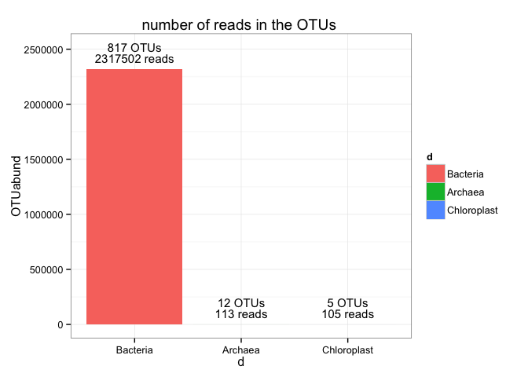

```r
data.frame(OTU.ID = OTU$OTU.ID, OTUabund = rowSums(OTU[, -1])) %>%
  left_join(TAX_wide, .) %>%
  mutate(d = replace(d, c == "Chloroplast", "Chloroplast")) %>%
  group_by(d) %>%
  summarise(OTUabund = sum(OTUabund), n_OTUs = n()) %>%
  ggplot( aes( x = d, y = OTUabund, fill = d))+
  geom_bar(stat = "identity")+
  geom_text(aes(y = OTUabund + 1e5, label = paste(OTUabund, "reads")), size = 4) +
  geom_text(aes(y = OTUabund + 2e5, label = paste( n_OTUs, "OTUs")), size = 4) +
  labs(title = "number of reads in the OTUs ")+
  theme_bw()
```

for further analysis we will only keep the OTUs that have been assigned to the domain `Bacteria` We clean the `OTU` table and the `TAX_wide` table of all other OTUs and export them. We also export a file containing all OTU’s that are assigned as `Bacteria` .

```r
TAX_wide %>%
  mutate(d = replace(d, c == "Chloroplast", "Chloroplast")) %>%
  filter( d == "Bacteria") %T>%
  {assign("BAC_OTUs", .$OTU.ID, pos = ".GlobalEnv" )} %>%
  write.table(., file = "OTU_docs/TAX_clean.txt", sep = "\t")

OTU %>%
  filter(OTU.ID %in% BAC_OTUs) %>%
   write.table(., file = "OTU_docs/OTU_clean.txt", sep = "\t")

BAC_OTUs %>% as.character %>% cat(., file = "OTU_docs/BAC_OTUs.txt", sep ="|")
```

to clean the file `numbered_OTU_wTax.fasta`from the sequences that we don’t want to keep, we move the analysis to Qiime where we can use the python script `filter_fasta.py`.

**the following code is run directly in the console as calling qiime with sytsem() doesn’t seem to work** The exact commands are included in this document but can’t be run as a script.

```bash
#macqiime
```

```bash
#grep -E -w -f OTU_docs/BAC_OTUs.txt OTU_docs/numbered_OTU_wTax.fasta > OTU_docs/OTU_BAC.txt
#sed -ibak -E 's/^>//' OTU_docs/OTU_BAC.txt
#filter_fasta.py -f OTU_docs/numbered_OTU_wTax.fasta -s OTU_docs/OTU_BAC.txt -o OTU_docs/numbered_OTU_wTax_clean.fasta
#grep -c -E '^>' OTU_docs/numbered_OTU_wTax_clean.fasta
```

next with proceed with construction of a phylogenetic tree. before the construction of the tree, we strip the phylogenetic information from the sequence label (otherwise all sequences are named by their full header). Then, we

- align the representative sequences against the greengen full-length 16S database (default in qiime) using the (default) pynast algorithm
- filter ‘all gaps’ positions
- build a tree with midpoint rooting and the (default) fasttree algorithm

```bash
# sed -E's/^(>OTU_[0-9]+);.+/\1/' <OTU_docs/numbered_OTU_wTax_clean.fasta> OTU_docs/numbered_OTU.fasta

# cd OTU_docs

# align_seqs.py -i numbered_OTU.fasta

# filter_alignment.py -i pynast_aligned/numbered_OTU_aligned.fasta -o pynast_aligned

# make_phylogeny.py -i pynast_aligned/numbered_OTU_aligned_pfiltered.fasta -r midpoint -o OTU97.tre
```

as we need an ultrametric tree to estimate phylogenetic diversity we need to make the tree ultrametric. We will use pathd8 to achieve this

```bash
# OTU_docs/PATHd8/PATHd8 OTU_docs/OTU97.tre OTU_docs/OTU97_um.tre
```

PATH8 produces a big file with lots of additional information that is not very relevant in our case. We can use `ape::read.tree` to extract the tree from the file and write it back as pure tree file. We can also use the opportunity to strip the additional `'` from the tree labels.

```r
TREE <- read.tree("OTU_docs/OTU97_um.tre")[[1]]
TREE$tip.label <- sub("'(\\w+)'", "\\1", TREE$tip.label)
write.tree(TREE, "OTU_docs/OTU97_um.tre")
```